# Red Wine Quality Exploratory Data Analysis by Saul Geller

```
## Number of missing values: 0
```

```
## Number of null values: 0
```

The dataframe contains around 1600 entries for various red wines. Each entry contains a quality rating score between 0 and 10, and 11 chemical properties, all with numerical values. There are no missing or NULL values so no data cleaning is necessary at this point. I did decide to change the column named “sulphates” to “sulfates” just to be more consistent with the spelling, and I also shortened some column names.

# Univariate Plots Section

```
##        X            fixed.acid       vol.acid       citric.acid
##  Min.   :   1.0   Min.   : 4.60   Min.   :0.1200   Min.   :0.000
##  1st Qu.: 400.5   1st Qu.: 7.10   1st Qu.:0.3900   1st Qu.:0.090
##  Median : 800.0   Median : 7.90   Median :0.5200   Median :0.260
##  Mean   : 800.0   Mean   : 8.32   Mean   :0.5278   Mean   :0.271
##  3rd Qu.:1199.5   3rd Qu.: 9.20   3rd Qu.:0.6400   3rd Qu.:0.420
##  Max.   :1599.0   Max.   :15.90   Max.   :1.5800   Max.   :1.000
##    res.sugar        chlorides        free.sulfur     total.sulfur
##  Min.   : 0.900   Min.   :0.01200   Min.   : 1.00   Min.   :  6.00
##  1st Qu.: 1.900   1st Qu.:0.07000   1st Qu.: 7.00   1st Qu.: 22.00
##  Median : 2.200   Median :0.07900   Median :14.00   Median : 38.00
##  Mean   : 2.539   Mean   :0.08747   Mean   :15.87   Mean   : 46.47
##  3rd Qu.: 2.600   3rd Qu.:0.09000   3rd Qu.:21.00   3rd Qu.: 62.00
##  Max.   :15.500   Max.   :0.61100   Max.   :72.00   Max.   :289.00
##     density             pH           sulfates         alcohol
##  Min.   :0.9901   Min.   :2.740   Min.   :0.3300   Min.   : 8.40
##  1st Qu.:0.9956   1st Qu.:3.210   1st Qu.:0.5500   1st Qu.: 9.50
##  Median :0.9968   Median :3.310   Median :0.6200   Median :10.20
##  Mean   :0.9967   Mean   :3.311   Mean   :0.6581   Mean   :10.42
##  3rd Qu.:0.9978   3rd Qu.:3.400   3rd Qu.:0.7300   3rd Qu.:11.10
##  Max.   :1.0037   Max.   :4.010   Max.   :2.0000   Max.   :14.90
##     quality
##  Min.   :3.000
##  1st Qu.:5.000
##  Median :6.000
##  Mean   :5.636
##  3rd Qu.:6.000
##  Max.   :8.000
```

Looking at the summary of the columns in the dataframe, nothing crazy stands out. There do seem to be some relatively high maximum values compared to the minimum and median values, indicating some potential outliers. The pH values also look surprisingly acidic, though I don’t know much about wine pH going into this project.

I also want to make a note of the units of the data, given by the data info text document provided by the authors of the dataset. Most of these columns are given in some form of density unit; the only exceptions being pH, percent alcohol, and the quality score. The unit g/dm^3, which applies to fixed acidity, volatile acidity, citric acid, residual sugar, chlorides, and sulphates, means grams per decimeter cubed. A decimeter cubed is also 1 liter, so more simply this unit is grams per liter.

The free sulfur dioxide and total sulfur dioxide are given in mg/dm^3 which is just milligrams per liter, and the overall density of the wine is given in g/cm^3 which is also grams per milliliter.

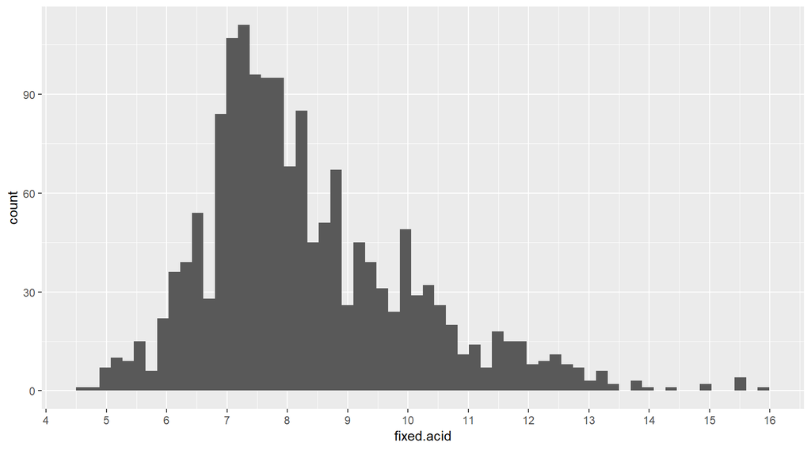

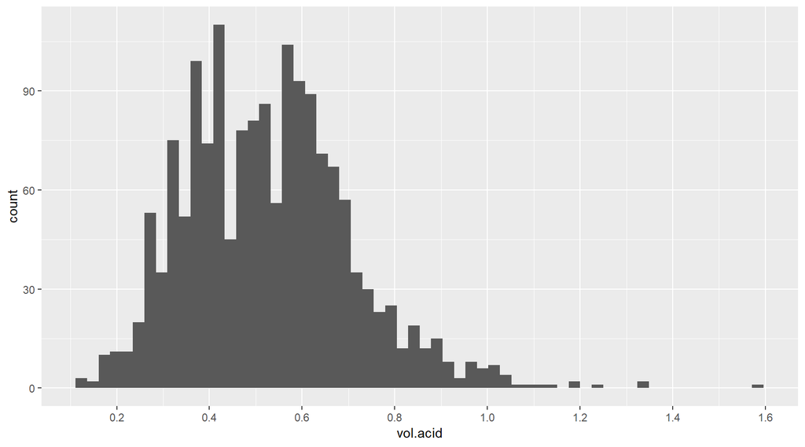

The fixed and volatile acidity level distributions both look fairly normal, but with some right-skewedness. Both these columns measure the density of different kinds of acid in the wine. Fixed acidity measures tartaric acidwhile volatile acidity measures acetic acid. High levels of acetic acid can cause a vinegar taste in the wine, as noted in the author provided data info text file.

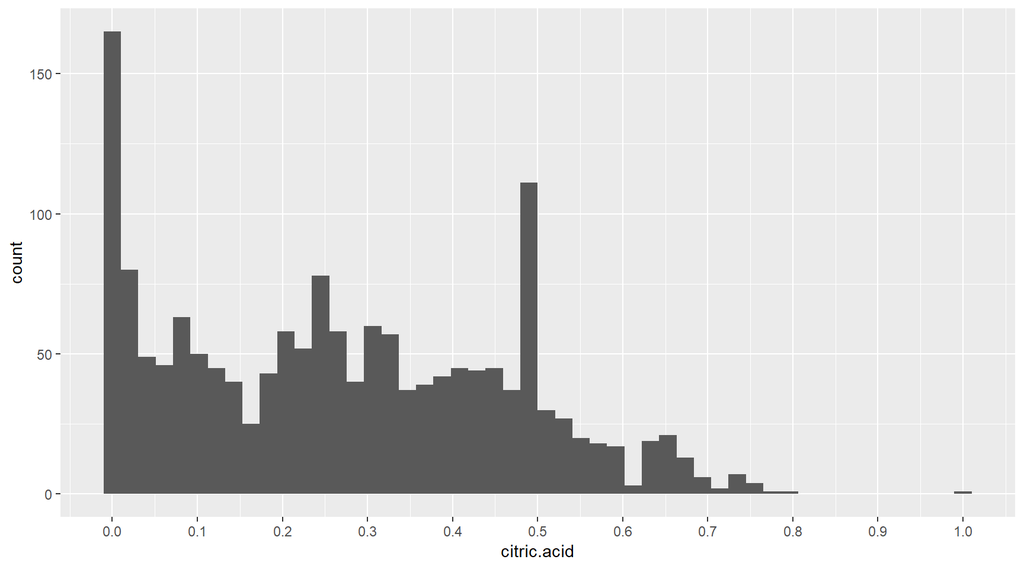

The citric acid distribution shows an unusually high number of wines at 0 and near 0.5 g/dm^3. Overall thedistribution does not appear very normal but other than those 2 irregular peaks, it looks like the count of wines with citric acid levels from 0 to 0.5 fluctuates and then starts falling off at higher citric acid levels. There is also an outlier near 1.

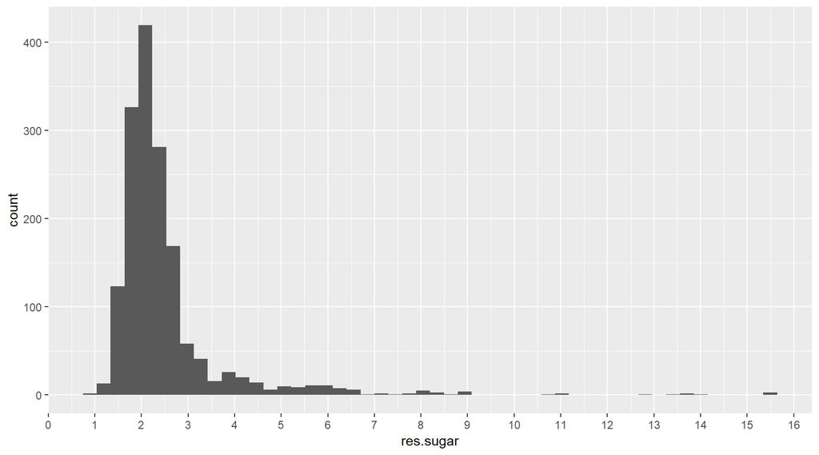

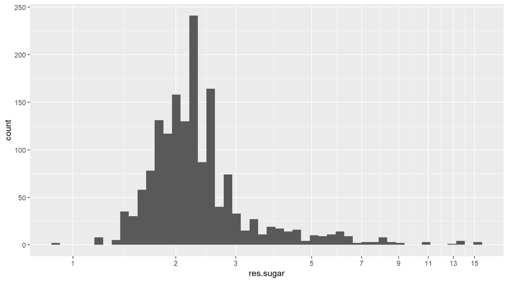

The original residual sugar distribution looks long tailed so I applied a logarithmic scale transformation. The transformed distribution appears much more normal than before, but is still somewhat long-tailed.

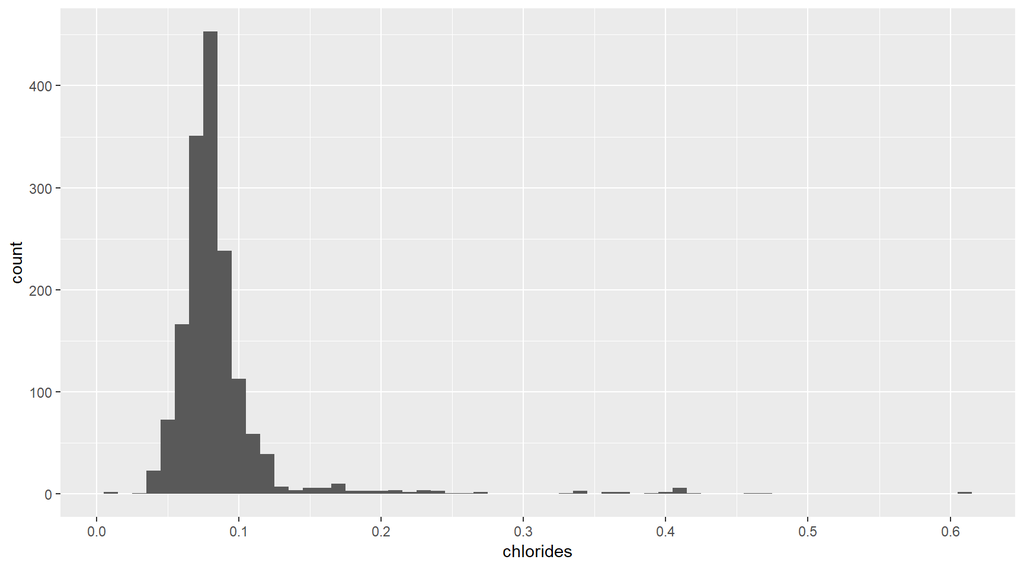

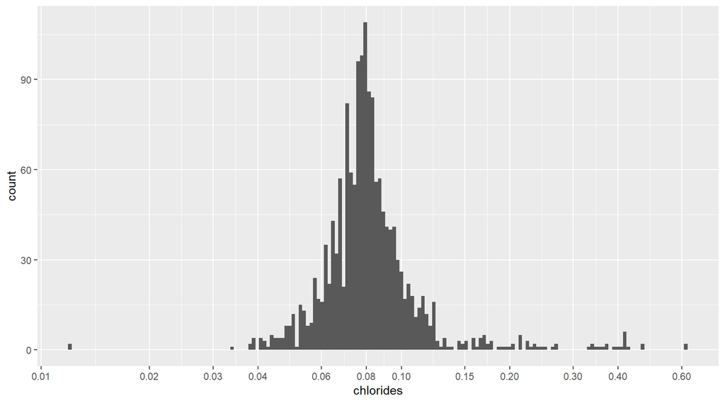

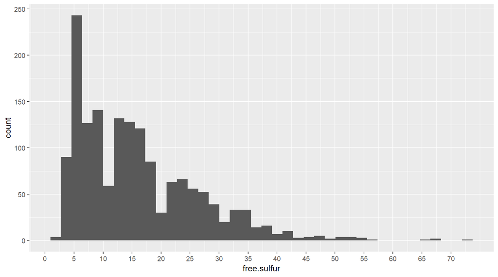

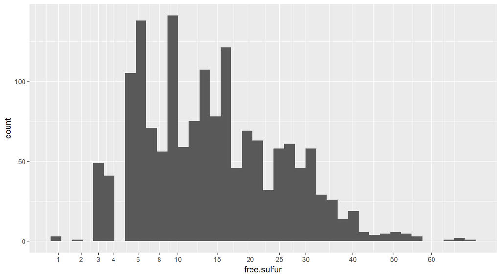

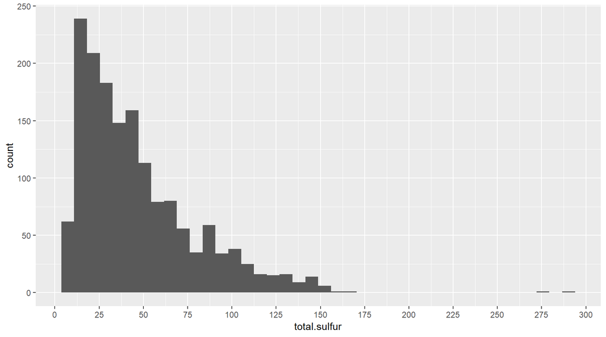

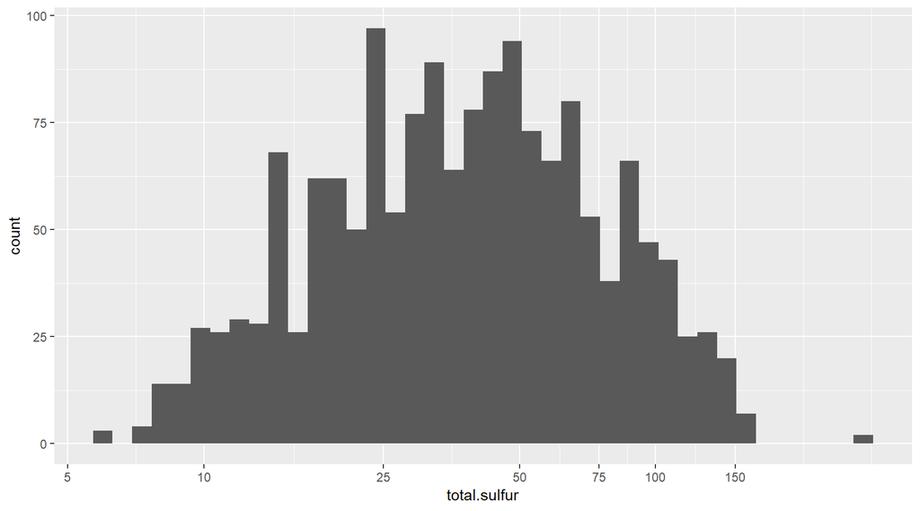

Sulfur dioxide (SO2) is a biproduct of fermentation, but most winemakers actually add significantly more of it as a preservative and anti-microbial agent. The SO2 can either be free, where it exists in equilibrium between its molecular form as well as two ionic forms in solution, or it can be bound, meaning its chemically attached to another compound in the wine. The total SO2 column is the combination of both free and bound SO2. Both SO2 distributions appear long-tailed, so I applied scale transformations to get them to look more normal.

For the Free SO2 distribution, a square root transformation worked best. There is an unusually large peak at around 5-6 but other than that the new distribution appears normal.

For the Total SO2 distribution, a logarithmic scale transformation worked better and overall it appears quite normal in the new graph, with its mean at around 46.5.

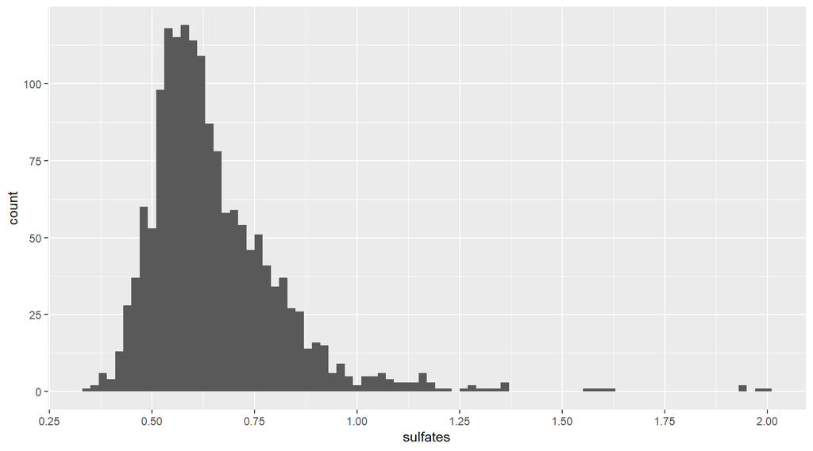

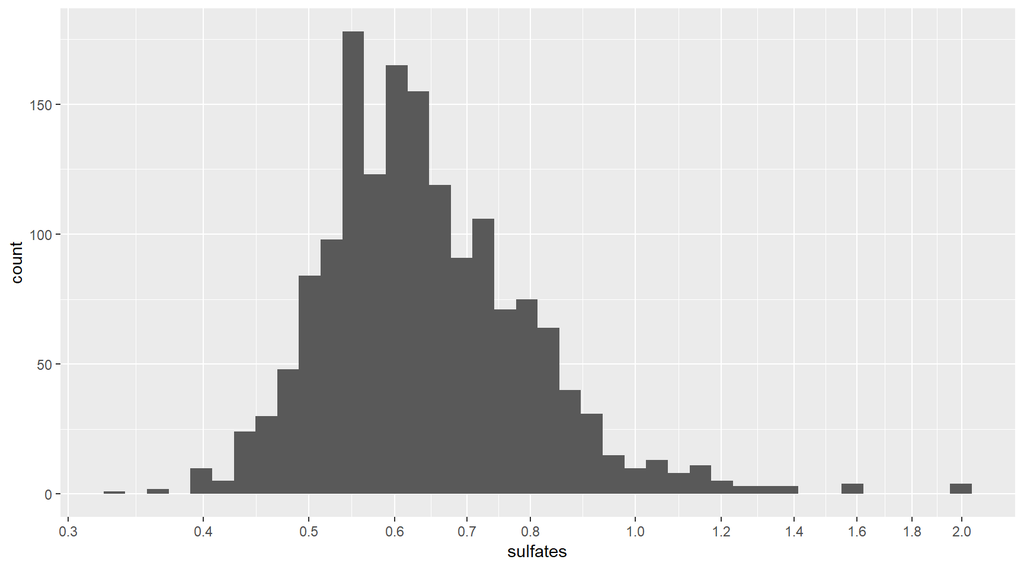

Sulfates are wine-additives that can add to the sulfur dioxide levels of the wine. The original distribution looked somewhat long-tailed and a logarithmic scale transformation makes the new graph look much more normal, with a mean of around 0.66.

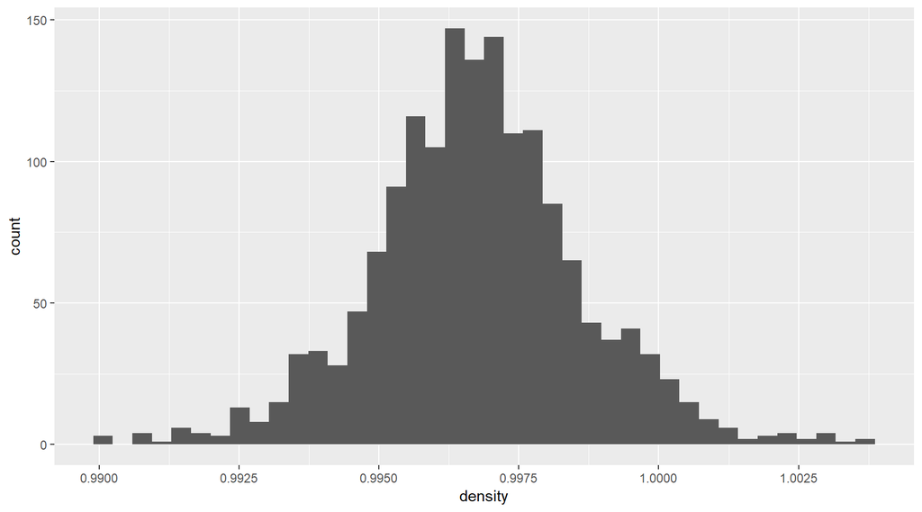

The wine density distribution looks quite normal, with all of its values very close to 1, the density of water. the distribution is not centered at 1 however. Most of the wines have a density slightly less than 1, and the overall mean is 0.997.

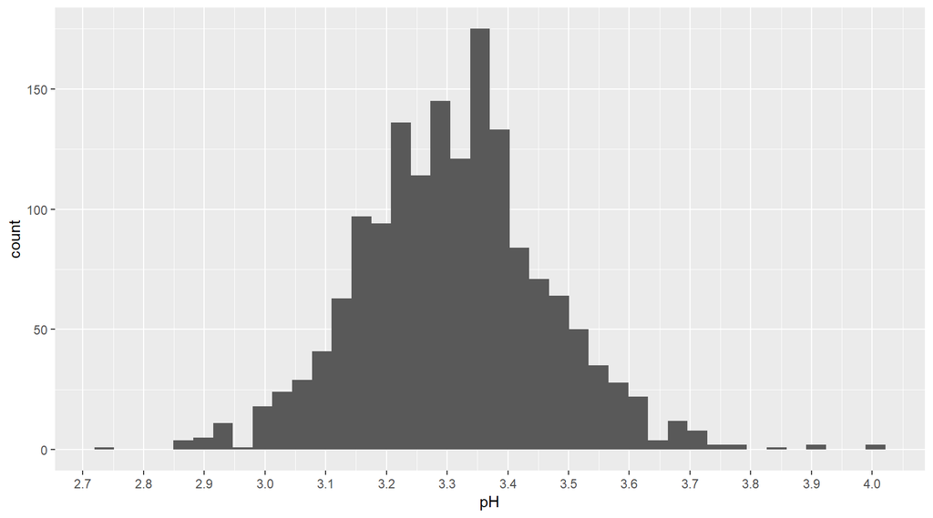

The pH is a measure of acidity based on the concentration of hydrogen cations in a solution. The typical scale goes from 0 to 14, with a pH of 7 being the pH of water and considered neutral. Anything less than 7 is acidic, and anything more than 7 is basic.

For this dataset, the pH distribution appears normal, centered around 3.3. All of the wines are below 7.

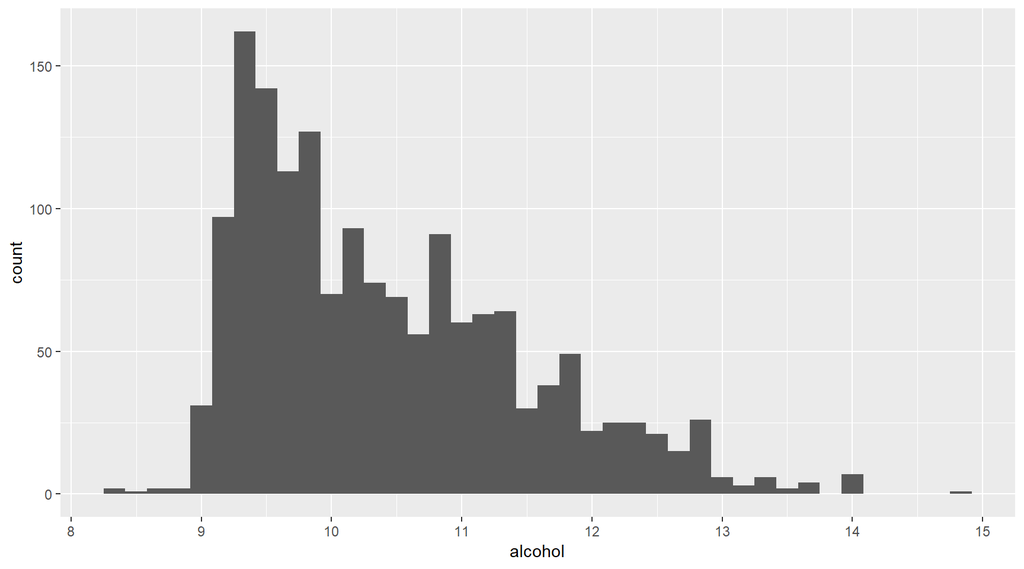

The percent alcohol distrubtion does not look normal. It is skewed right, with a large peak around 9.5, and then the counts decrease as the percent alcohol increases. Applying square root or logarithmic scale transformations does not normalize this distribution.

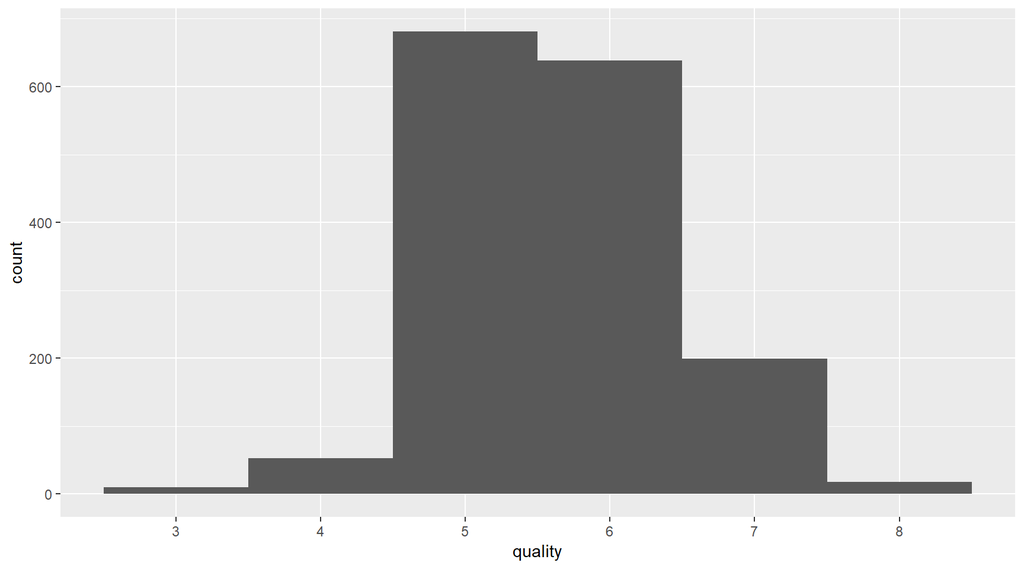

Quality scores go from 0 to 10, but in this dataset, only scores from 3 to 8 actually occurred. The most common scores were 5 and 6, and the overall distribution looks normal. The mean quality score is 5.6.

# Univariate Analysis

### What is the structure of your dataset?

The dataset is made up of 13 columns, with 1599 observations. The first column is just the unique number given to each wine in sequence, going from 1 to 1599, so really there are only 12 variables. Of those 12 variables, 11 are measures of various chemical properties, mainly densities of particular compounds in the wine. The 12th variable is the quality score of the wine.

All 12 variables are numerical, with no real ordered factor variables. That said, the quality column can be treated like an ordered factor variable because it is an integer score that can only go from 0 to 10. And in this dataset, it only goes from 3 to 8.

### What is/are the main feature(s) of interest in your dataset?

The main feature of this dataset is the quality score, which goes from 0 to 10 with a higher score signifying a better rated wine.

### What other features in the dataset do you think will help support your investigation into your feature(s) of interest?

Besides the quality score, the other features of the dataset are all chemical properties of the wine and may be linked to higher or lower quality wine.

### Did you create any new variables from existing variables in the dataset?

I did not add any columns to the data. I thought about adding a column for bound sulfur dioxide, which would be the total sulfur dioxide subtracted by the free sulfur dioxide, but after investigating why sulfur dioxide levels are measured, plus the total sulfur dioxide will of course be related to the bound sulfur dioxide, I decided against it.

### Of the features you investigated, were there any unusual distributions? Did you perform any operations on the data to tidy, adjust, or change the form of the data? If so, why did you do this?

The dataset did contain some unusual distributions, but most were fairly normal, and some became normal after a scale transformation. Using logarithmic or square root scale transformations on any distributions that appeared long-tailed typically helped to normalize them, except for the alcohol content distribution.

# Bivariate Plots Section

```
##              fixed.acid vol.acid citric.acid res.sugar chlorides
## fixed.acid         1.00    -0.26        0.67      0.11      0.09
## vol.acid          -0.26     1.00       -0.55      0.00      0.06
## citric.acid        0.67    -0.55        1.00      0.14      0.20
## res.sugar          0.11     0.00        0.14      1.00      0.06
## chlorides          0.09     0.06        0.20      0.06      1.00
## free.sulfur       -0.15    -0.01       -0.06      0.19      0.01
## total.sulfur      -0.11     0.08        0.04      0.20      0.05
## density            0.67     0.02        0.36      0.36      0.20
## pH                -0.68     0.23       -0.54     -0.09     -0.27
## sulfates           0.18    -0.26        0.31      0.01      0.37
## alcohol           -0.06    -0.20        0.11      0.04     -0.22
## quality            0.12    -0.39        0.23      0.01     -0.13
##              free.sulfur total.sulfur density    pH sulfates alcohol
## fixed.acid         -0.15        -0.11    0.67 -0.68     0.18   -0.06
## vol.acid           -0.01         0.08    0.02  0.23    -0.26   -0.20
## citric.acid        -0.06         0.04    0.36 -0.54     0.31    0.11
## res.sugar           0.19         0.20    0.36 -0.09     0.01    0.04
## chlorides           0.01         0.05    0.20 -0.27     0.37   -0.22
## free.sulfur         1.00         0.67   -0.02  0.07     0.05   -0.07
## total.sulfur        0.67         1.00    0.07 -0.07     0.04   -0.21
## density            -0.02         0.07    1.00 -0.34     0.15   -0.50
## pH                  0.07        -0.07   -0.34  1.00    -0.20    0.21
## sulfates            0.05         0.04    0.15 -0.20     1.00    0.09
## alcohol            -0.07        -0.21   -0.50  0.21     0.09    1.00
## quality            -0.05        -0.19   -0.17 -0.06     0.25    0.48
##              quality
## fixed.acid      0.12
## vol.acid       -0.39
## citric.acid     0.23
## res.sugar       0.01
## chlorides      -0.13
## free.sulfur    -0.05
## total.sulfur   -0.19
## density        -0.17
## pH             -0.06
## sulfates        0.25
## alcohol         0.48
## quality         1.00
```

Here is a correlation matrix of all columns in the dataset, excluding the first column which is just a sequential list of the entries. Looking at the main output in the quality column, the chemical property with the strongest linear relationship is the alcohol content with a correlation of 0.48. The quality score’s relationship with volatile acid is also relatively strong. And the weakest relationships are with residual sugar, free sulfur dioxide, and pH.

Looking at other variables, I see density has a relatively strong positive linear relationship with fixed acidity level and an inverse linear relationship with alcohol content. Fixed acidity level also has a direct relationship with citric acid content, which makes sense as citric acid levels should directly contribute to fixed acid levels since citric acid is a fixed acid.

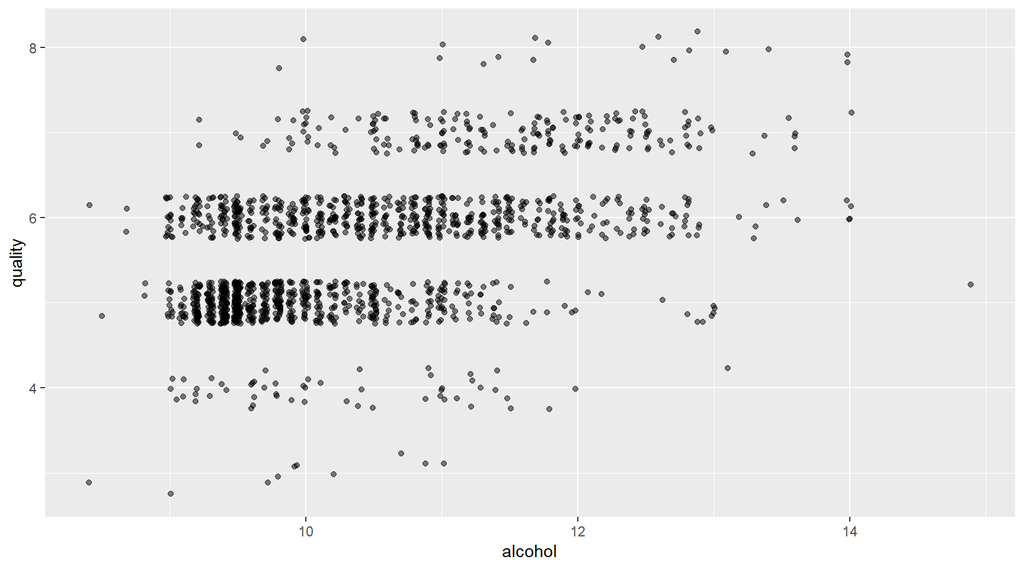

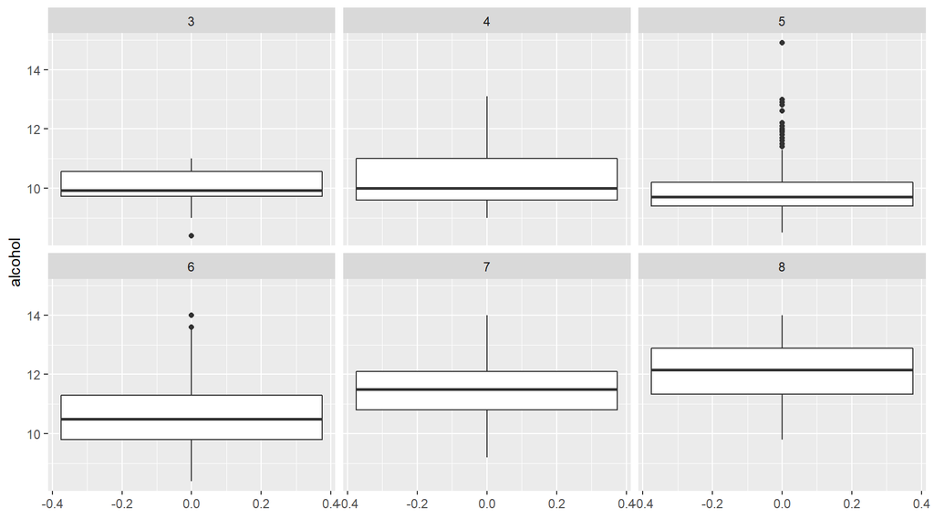

Alcohol content and quality score had a correlation of 0.48. The scatterplot shows that wines with scores of 8 and 7 typically have more alcohol than wines with a score of 3 or 4.

Using boxplots gives a better picture of the data. From this I see that as wine quality score goes up from 6 to 7 to 8, alcohol content also increases for the bulk of the wines. However, ignoring the many outliers present in wines with a score of 5, we can see the bulk of those wines actually had less alcohol content than for wines with a score of 4.

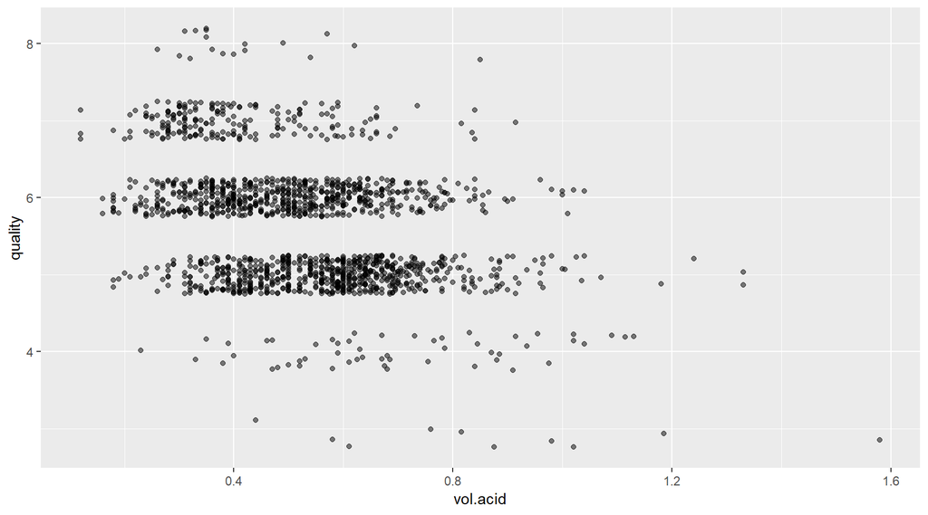

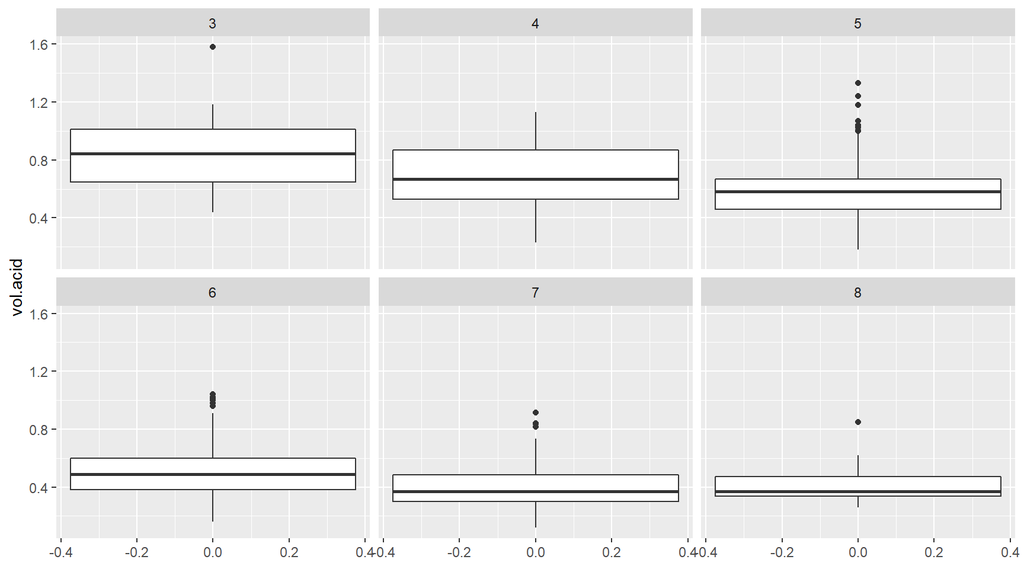

Again, the relationship in the scatter plot is apparent, though this time its an inverse relationship. Looking at the boxplots, wines with a score of 8 and 7 are similar, but as the wines’ score gets lower, volatile acid level increases in a pretty linear fashion.

Volatile acid level is basically the amount of acetic acid in the wine, which at high levels will cause a vinegary taste.

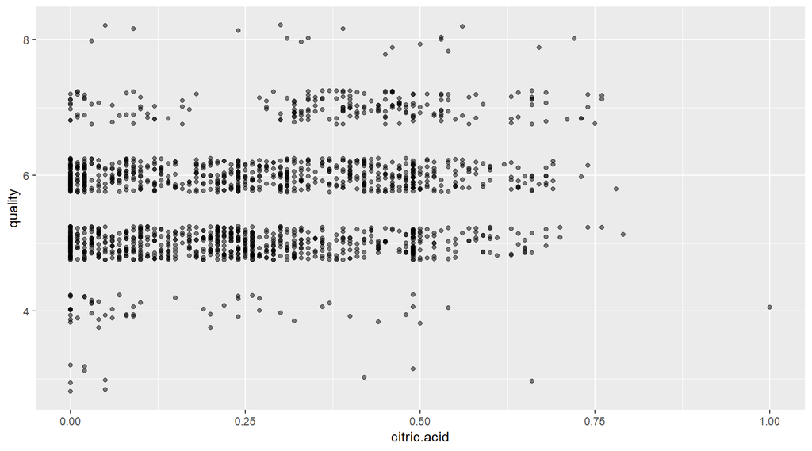

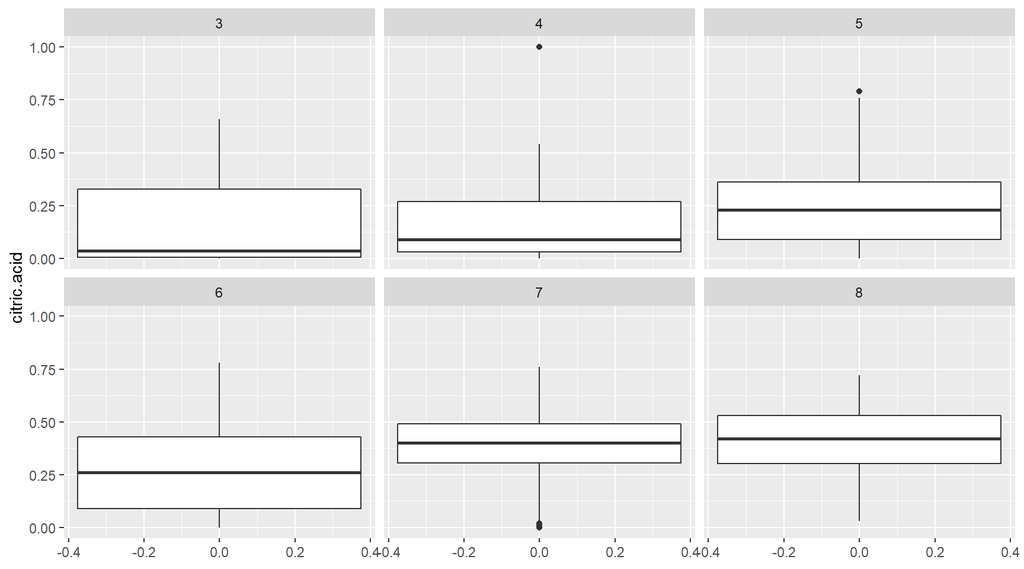

Looking specifically at wines with a score of 7 vs wines with a score of 6, the 6 score wines are pretty evenly spread in terms of of citric acid level, but 7 score wines have a clear lack of data points around 0.2 g/dm^3 citric acid, with a grouping of outlier points that are have lower citric acid levels.

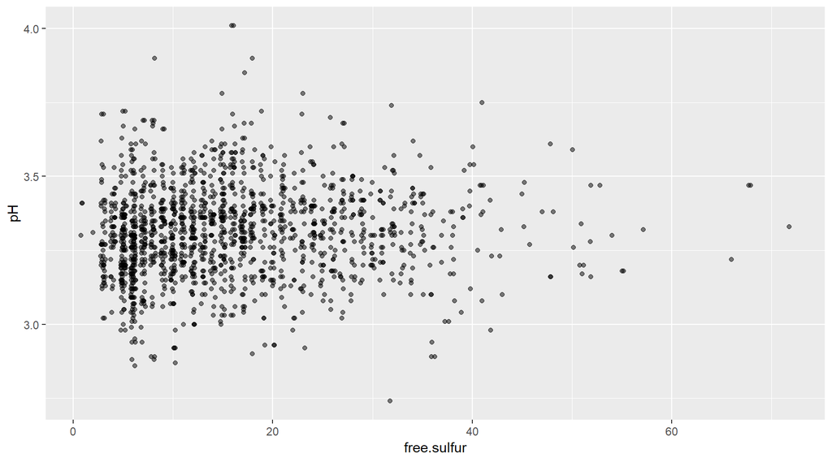

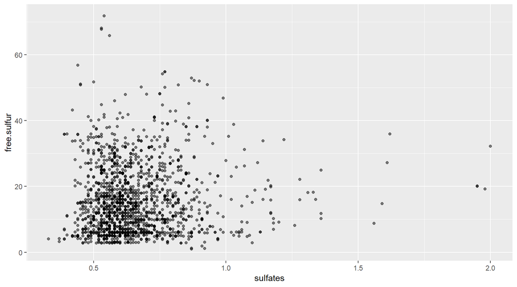

One thing I was curious about was how free sulfur dioxide levels related to some of the other variables. I looked at free sulfur versus pH as well as free sulfur vs sulfates.

Free sulfur exists in a chemical equilibrium between multiple states. It will exist as a gas, molecular sulfur dioxide, as a bisulfite ion with a negative charge, and as a sulfite ion with two negative charges, by giving up a hydrogen ion. This relationship made me wonder if free sulfur dioxide levels could have a link to pH. According to the correlation matrix there was no linear relationship but I still wanted a closer look.

Sulfates is a measure of how much sulfate preservatives were added to the wine. The authors say that these additives should add to free sulfur levels but according to the correlation matrix there was no relationship between them.

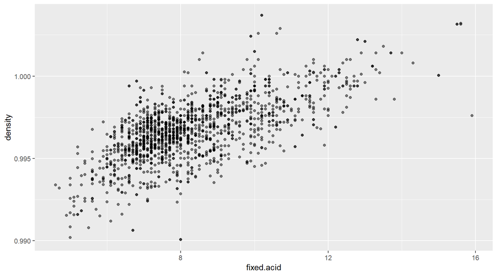

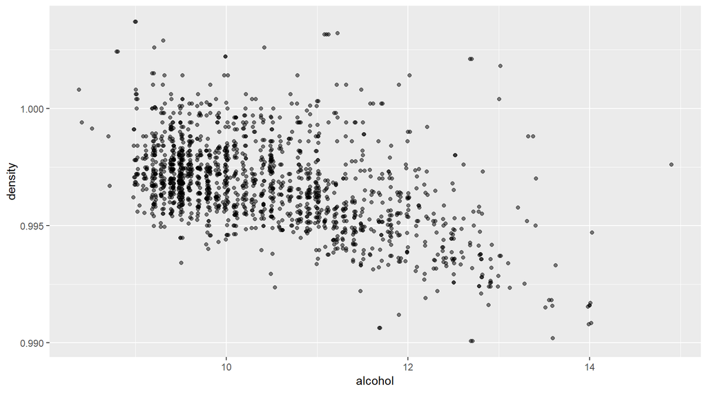

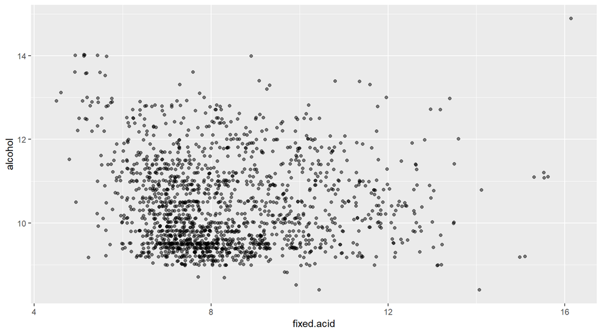

The density of the wines was moderately correlated to fixed acidity level and alcohol content. Alcohol, specifically ethanol, has a lower density than water, so a wine with higher alcohol content having a lower density makes sense. But, I wasn’t sure how fixed acidity level relates. Looking at the fixed acidity vs the density, the direct linear relationship is very noticeable.

Comparing fixed acidity to alcohol content, there’s no real pattern that I can see, and the correlation is also quite weak which leads me to believe that however fixed acidity level and density are linked, its independent from alcohol content’s effect on density.

# Bivariate Analysis

### Talk about some of the relationships you observed in this part of the investigation. How did the feature(s) of interest vary with other features in the dataset?

The main feature of this dataset, the quality score, correlated most strongly with alcohol content and volatile acid level. Higher alcohol levels were associated with better quality scores and higher volatile acid levels were associated with lower quality scores. Percent alcohol having this strong an effect on quality (with a correlation of 0.48) surprised me, as I don’t think a wine needs to be very strong to be good. The quality’s relationship with volatile acidity is far less surprising as according to the authors, a high volatile acidity level means a vinegary taste.

### Did you observe any interesting relationships between the other features (not the main feature(s) of interest)?

Density had a surprisingly strong relationship with fixed acidity level, and free sulfur dioxide level had a surprisingly weak to no relationship with both pH and sulfates added.

### What was the strongest relationship you found?

Fixed acidity level had the strongest relationships in the dataset, with a correlation of 0.67 to citric acid level, 0.67 to density, and -0.68 to pH. Most of these relationships are not suprising. Citric acid is a type of fixed acid so of course they are related. And having a lot of fixed acid will of course lower the pH. However, as stated previously, density having a moderately strong correlation with fixed acidity level was unanticipated.

# Multivariate Plots Section

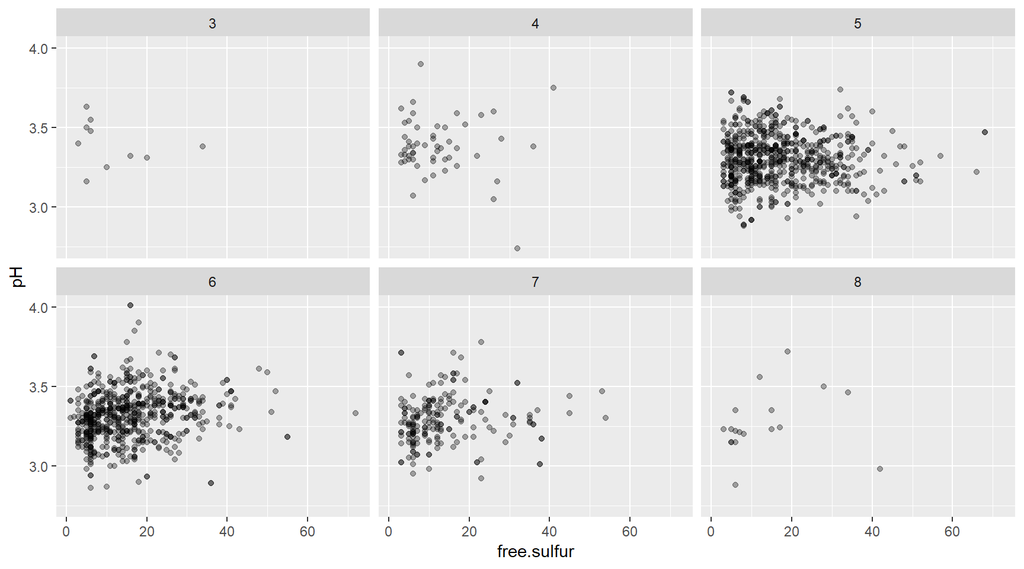

Here is a depiction of free sulfur dioxide vs pH over different qualities. The distributions are all pretty similar. Wines with an 8 quality score look somewhat positively correlated but with too few points its probably not statistically significant.

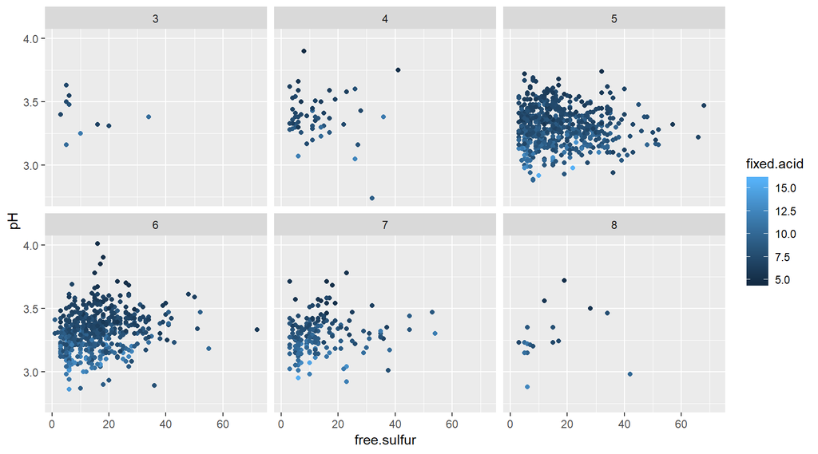

Here is free sulfur vs pH over different qualities, with a color gradient representing the fixed acidity level. Higher fixed acidity levels causes a lower pH, and I wanted to see if maybe that effect was masking any effects free sulfur dioxide could have on the pH.

Darker colors are more common at higher levels of pH, which was already shown in the bivariate section looking at the relationship between fixed acidity and pH. I don’t see anything that indicated fixed acidity levels are masking free sulfur’s effect on pH, and this holds true for all qualities of wine.

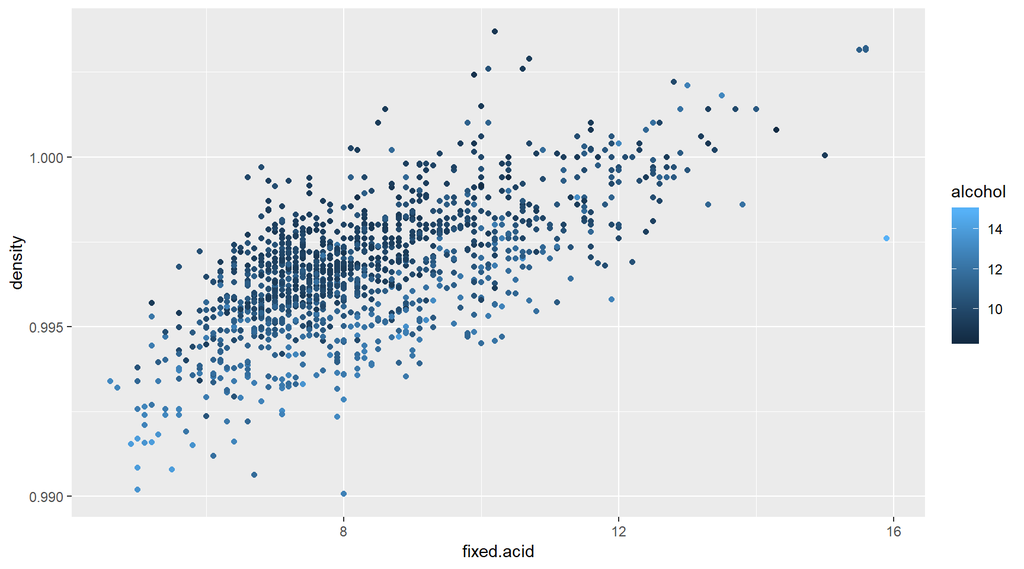

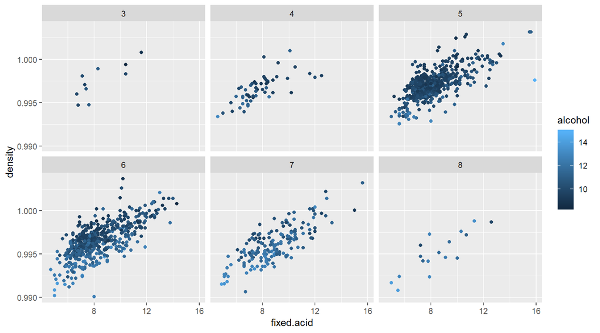

I then looked at the interesting relationship between density and fixed acidity. Density is negatively associated with alcohol content because alcohol is less dense than water, but I wasn’t sure why fixed acidity had any relationship with density.